# All Plant iNaturalist Observations Connecticut

Steven DiFalco

9/5/2019

```r
library(plyr); library(ggplot2); library(tidyverse)
```

```r
all_ct <- read.csv("observations-60137.csv")
all_ct[1:5,32:34]
```

```
##         species_guess         scientific_name          common_name
## 1 Pink Lady's Slipper      Cypripedium acaule  pink lady's slipper
## 2 Virginia spiderwort Tradescantia virginiana  Virginia spiderwort
## 3        black cherry         Prunus serotina         black cherry
## 4      swamp dewberry          Rubus hispidus       swamp dewberry
## 5        Prickly Pear        Opuntia humifusa eastern prickly pear
```

#### Looking at the raw data, there are a lot of fields that may not apply depending on your goal. The next section will help clean up the data and keep only the columns I’d like to focus on

```r
columns.keep <- c('id','observed_on','scientific_name', 'user_login','common_name', 'taxon_id','quality_grade','place_guess','latitude','longitude','url')
all_ct <- all_ct[,columns.keep]
head(all_ct)
```

```
##    id observed_on         scientific_name   user_login
## 1 337  2008-05-31      Cypripedium acaule stellaoleary
## 2 340  2008-06-01 Tradescantia virginiana stellaoleary
## 3 380  2008-05-31         Prunus serotina stellaoleary
## 4 381  2008-05-31          Rubus hispidus stellaoleary
## 5 506  2008-07-04        Opuntia humifusa stellaoleary
## 6 515  2008-07-19      Circaea canadensis stellaoleary
##                        common_name taxon_id quality_grade
## 1              pink lady's slipper    47588      research
## 2              Virginia spiderwort   130991      research
## 3                     black cherry    54834      research
## 4                   swamp dewberry    69713      research
## 5             eastern prickly pear    47894      research
## 6 broadleaf enchanter's nightshade   204271      research
##                           place_guess latitude longitude
## 1                          Clinton Ct 41.27860 -72.52720
## 2                          Clinton ct 41.27080 -72.52300
## 3                         Clinton, CT 41.31740 -72.55810
## 4 Peter's Memorial Woods, Clinton, CT 41.30700 -72.51320
## 5                     Connecticut, US 41.39759 -72.40626
## 6                    Clinton, CT, USA 41.31820 -72.56630
##                                           url
## 1 http://www.inaturalist.org/observations/337
## 2 http://www.inaturalist.org/observations/340
## 3 http://www.inaturalist.org/observations/380
## 4 http://www.inaturalist.org/observations/381
## 5 http://www.inaturalist.org/observations/506
## 6 http://www.inaturalist.org/observations/515
```

#### Get date information into the proper format. This is a bit of a pain to do, but thanks to Micah Freedman’s script, I was able to get it done easier. In this example, I will not use day or month, but kept the code to separate out the date just so it was available.

```r
#create a new column for Julian day of observation
all_ct$julian.date <- format(as.Date(all_ct$observed_on), "%j")

#convert this to a continuous numeric variable
all_ct$julian.date <- as.numeric(all_ct$julian.date)

#create a new column for month of observation
all_ct$month <- format(as.Date(all_ct$observed_on), "%m")

#assign names for months (revalue function requires plyr library)
all_ct$month <- revalue(all_ct$month, c('01' = 'January', '02' = 'February', '03' = 'March', '04' = 'April', '05' = 'May', '06' = 'June', '07' = 'July', '08' = 'August', '09' = 'September', '10' = 'October', '11' = 'November', '12' = 'December'))

#rearrange so months are in chronological order
all_ct$month <- factor(all_ct$month, levels = c('January','February','March','April','May','June','July','August','September','October','November','December'))

#adds year of observation to another column
all_ct$year <- format(as.Date(all_ct$observed_on), "%Y")
```

#### I was interested to identify whether species observed were invasive or native. To do that, I downloaded a vascular plant list with that information, extracted ‘origin’ category, and combined this with the inat observations.

```r
#vascular plant list for state of CT (https://sites.google.com/a/conncoll.edu/vascular-plants-of-connecticut-checklist/)
CT_Flora_Checklist <- read.csv("CT Flora Checklist 8-1-14.csv")

#keep certain columns from dataset
column_keep <- c('Current.Scienticfic.Name','Common.Name.s.', 'Origin')
CT_Flora_Checklist <- CT_Flora_Checklist[,column_keep]

#get rid of the extraneous things at end of scientific name
CT_Flora_Checklist_sep <- separate(CT_Flora_Checklist, Current.Scienticfic.Name, into = c('genus', 'species'),sep = " ")
#re-combine genus and species in neat form
CT_Flora_Checklist_new <- unite(CT_Flora_Checklist_sep, 'scientific_name', c('genus', 'species'), sep= " ")

#Count inat observations by scientific name
all_ct_scientific <- all_ct %>%
  group_by(scientific_name)%>%
  dplyr::summarise(n=n())%>%
  filter(n>5)

##join dataset from all obs and CT Flora to get which ones are invasive/native.
combined_datasets <- dplyr::inner_join(all_ct_scientific, CT_Flora_Checklist_new, by= "scientific_name")
write.csv(combined_datasets, file = "inat_combined.csv")

combined_data_highest <- combined_datasets %>%
  filter(n>100) %>%
  arrange(desc(n))

combined_data_highest$Origin <- revalue(combined_data_highest$Origin, c('E' = 'Invasive', 'I' = 'Invasive', 'N' = 'Native'))

write.csv(combined_data_highest, file = "inat_top30.csv")
```

```r
####In the flora CSV there were a few species with multiple entries

#simplified the common names of these species
inat_top30 <- read.csv("inat_top30.csv")

#grouping data, with removing two specific users points collected all same day/location
all_ct_group <- all_ct %>%
  group_by(scientific_name, latitude, longitude)%>%
  dplyr::summarise(n=n())

#join original dataset with invasive codings
All_CT_withOrigin <- dplyr::left_join(all_ct_group, CT_Flora_Checklist_new, by = "scientific_name")
```

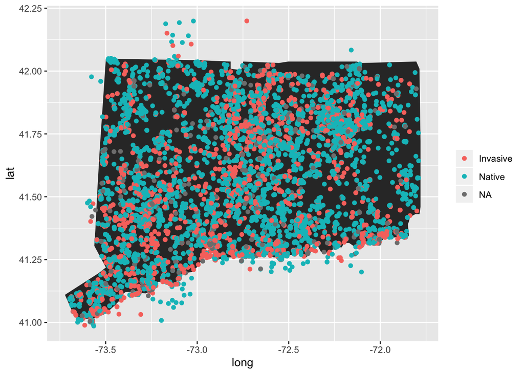

```r
All_CT_withOrigin$Origin <- revalue(All_CT_withOrigin$Origin, c('E' = 'Invasive', 'I' = 'Invasive', 'N' = 'Native'))

#map of ct
states <- map_data("state")
CT_map <- subset(states, region %in% c("connecticut"))

ggplot(data= CT_map)+
  geom_polygon(aes(x=long, y= lat))+
  geom_point(data = All_CT_withOrigin, aes(x=longitude, y = latitude, color = All_CT_withOrigin$Origin), na.rm= TRUE)+
  theme(legend.title = element_blank())
```

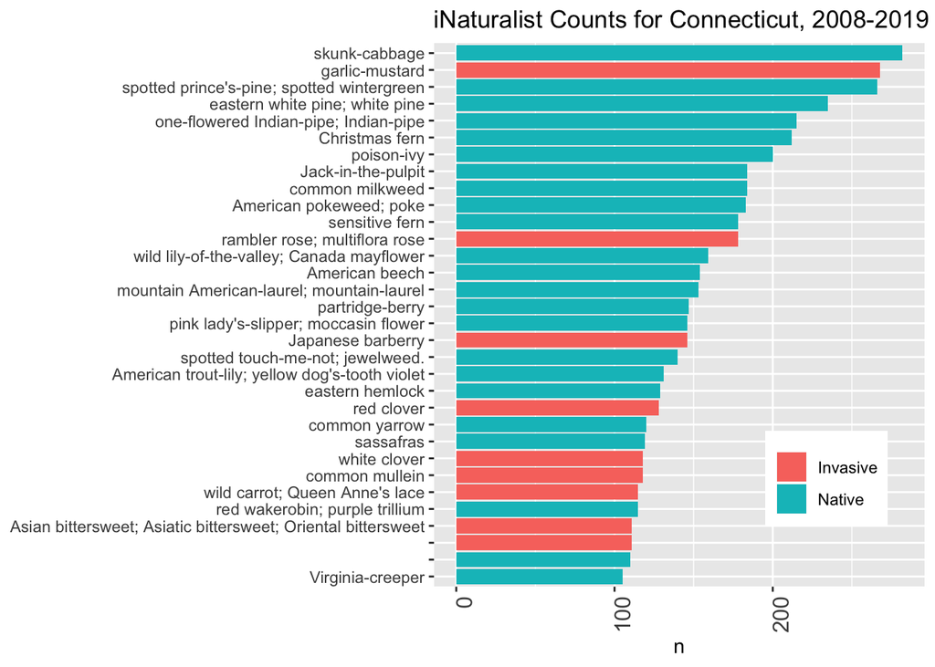

```r
ggplot(data= inat_top30, aes(x = reorder(Common.Name.s., n), y= n , fill = Origin)) + #change to -n if want aescending order or descending in other rotation
  geom_bar(stat= "identity", position = "dodge" ) +
  theme(axis.text.x = element_text(angle = 90, hjust=1, vjust = 1, size = 12))+
  xlab(NULL)+
  labs(title = "iNaturalist Counts for Connecticut, 2008-2019", size = 12)+
  theme(legend.position = c(0.8, 0.2))+
  theme(legend.title = element_blank())+
  coord_flip()
```